# Cleaning Script - Risk Polarization

2025-02-19

# General Information

This R script was written to clean the datasets from Limesurvey, from which we got batch wise data.

In the initial batch, the dataset only included the variable “starting language”, rather than “Country”, which would have directly indicated participants’ locations. We had initially assumed that surveys were distributed in English to participants in the United States and in German to those in Germany. However, this assumption proved incorrect. Fortunately, this issue can be resolved using the RID and Country list provided by Cint, so we can match the participants to their country of origin.

It should also show which analysis was done to determine speeders from non-speeders. Given our concerns of data quality - particularly due to the unexpectedly high numbers of speeders - various response time thresholds were established. This allows for the creation of multiple datasets, with different quality criteria, enabling comparisons to assess whether analytical results vary depending on data quality. Higher thresholds are expected to yield datasets with more reliable and genuine responses compared to lower ones.

At the end, one excel file is created with several sheets, with each subsequent sheet representing a dataset of progressively higher data quality:  
- Raw data only  
- Cleaned dataset with no lower limit, but removing the top 5% of participants on their full duration  
- Cleaned dataset with a lower limit of 3 minute, while removing the top 5% of participants on their full duration  
- Cleaned dataset with a lower limit of 5 minute, while removing the top 5% of participants on their full duration

The three bottom datasets are the clean ones, each having their top outliers removed while either having a lower threshold of either 0, 3, or 5 minutes.

## Used packages

```r
library(tidyverse)
library(readxl)
library(visdat)
library(XLConnect)
library(knitr)
```

## Loading Data

First of is reading in the datasets, while also joining the first batch of data with the mentioned list Cint has provided to match participant with their Country.

```r
df_raw <- read_excel("results-survey224442-5_countryIDs.xlsx", sheet = 1) # first batch of data prior to country ID (country will have to be matched with country ID from the same file)
US_ID <- read_excel("results-survey224442-5_countryIDs.xlsx", sheet = "US", col_names = "US_ID")
DE_ID <- read_excel("results-survey224442-5_countryIDs.xlsx", sheet = "DE", col_names = "DE_ID")

# match df_raw by country ID with the RID to create the column "Country"
df_raw <- df_raw %>% mutate(Country = case_when(RID %in% US_ID$US_ID ~ "US",
                                                RID %in% DE_ID$DE_ID ~ "DE",
                                                .default = NA))


df_new <- read_excel("results-survey224442-10.xlsx") # second batch after Country ID
df_newer <- read_excel("results-survey224442-10v2.xlsx") # third batch
```

We can see that there are still some participants in the first dataset where their Country variable is empty. Because all Germans in the list were found, we assume that the rest are from the US:

```r
df_raw %>% group_by(Country) %>%
   summarize(n = n())
```

```
## # A tibble: 2 × 2
##   Country     n
##   <chr>   <int>
## 1 DE        556
## 2 <NA>      733
```

So we will impute “US” into these Country with missing values:

```r
df_raw <- df_raw %>% mutate(Country = if_else(is.na(Country) == TRUE, "US", Country))

df_raw %>% group_by(Country) %>%
   summarize(n = n())
```

```
## # A tibble: 2 × 2
##   Country     n
##   <chr>   <int>
## 1 DE        556
## 2 US        733
```

Combine the data:

```r
# take same column names from new dat from the names of old dat
old_name <- colnames(df_raw)


new_dat_filtered <- df_new %>%
   select(Country, old_name)

newer_dat_filtered <- df_newer %>%
   select(Country, old_name)

combined_dat <- df_raw %>%
   select(Country, old_name) %>%
   rbind(new_dat_filtered, newer_dat_filtered)
```

Visualize the data:

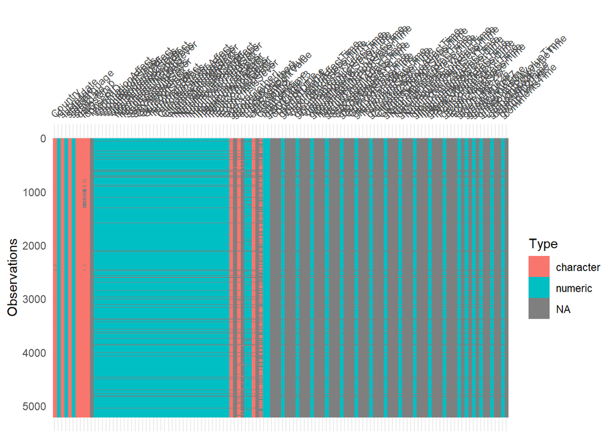

```r
vis_dat(combined_dat, sort_type = F)
```

Since several columns are consistently empty, they will be removed. For example, individual timestamps for specific risk-related questions were not recorded; instead, only the group timestamp was captured when all three dimensions of a risk were answered on the same page.

```r
# lookup which of these column only contain missing values without any useful information
empty_cols <- which(colSums(is.na(combined_dat)) == nrow(combined_dat))

# select only the column with at least one value
combined_dat_selected <- combined_dat[,-empty_cols]
```

And lastly filter for all those who gave consent, gave yes in the datacontrol question **and** are above 18 years old.

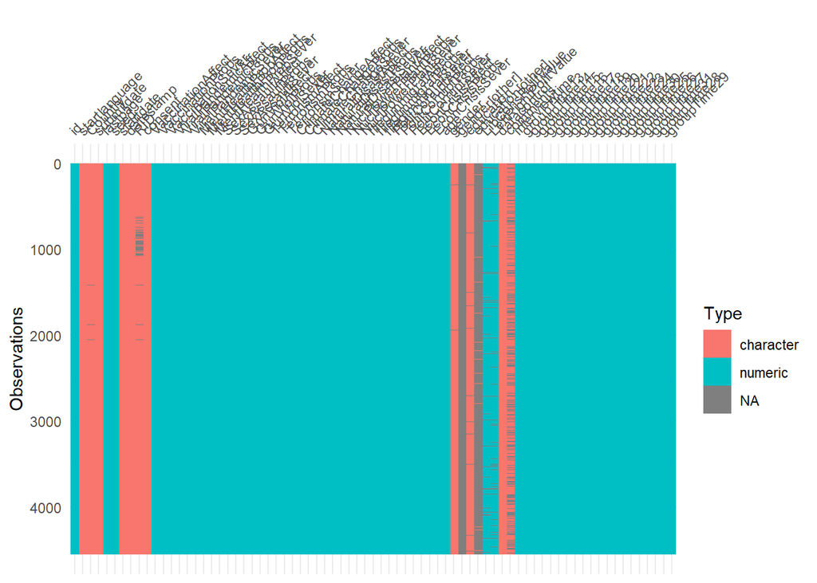

```r
combined_dat_yes_only <- combined_dat_selected %>%
  filter(consent == "I agree with this declaration of consent and the processing of my personal data" & datacontrol == "Yes" & age >= 18) %>%
  select(id, startlanguage, Country, everything())

vis_dat(combined_dat_yes_only, sort_type = F)
```

Some columns are still somewhat missing (other gender, other education etc) which is to be expected.

## Removing Duplicates

Checking that we do not have duplicates, by checking the RID, the identifier for each participant:

```r
combined_dat_yes_only %>%
   group_by(RID) %>%
   summarize(n_RID = n()) %>%
   filter(n_RID > 1)%>%
   kable()
```

| RID | n_RID |
| --- | --- |
| 59777361 | 2 |
| 673f56b4-6085-7a7a-b76f-1f207a6c6631 | 2 |
| 67434442-d67b-5ba1-e546-d925ba30c5a8 | 2 |
| 6743541f-3349-5c11-cd60-51687815278a | 2 |
| 674f3931-3ed6-b6f7-4ae8-82bdd3389a61 | 2 |
| 675697ce-d5b6-a7d7-ce6b-fa5c28bd3331 | 2 |
| 67569b9d-071b-8e51-d360-e717e5ca3c83 | 2 |
| 6756b21c-134f-fe71-5fff-60047bc7c75f | 2 |
| 6757330a-bf8d-9898-32ef-de779f7cfb19 | 2 |
| 675998be-92e1-d79f-2fd5-fc2efc183f58 | 2 |
| 675b3aab-6559-b6a9-2c0f-2e25fdf06260 | 2 |
| 67a23389-67a0-ffe7-11d8-ce362dd1f74f | 2 |
| NA | 255 |

Some duplicate RID, but also over 200 where RID is not given…  
Let’s have a look at all these duplicates.

```r
duplicate_RID <- combined_dat_yes_only %>%
   group_by(RID) %>%
   summarize(n_RID = n()) %>%
   filter(n_RID == 2) %>%
   pull(RID)

removed_duplicates <-  combined_dat_yes_only %>% filter(RID %in% duplicate_RID)
removed_duplicates %>% select(id, Country, startdate, RID)
```

```
## # A tibble: 24 × 4
##       id Country startdate           RID
##    <dbl> <chr>   <chr>               <chr>
##  1   258 US      2024-11-21 16:50:22 673f56b4-6085-7a7a-b76f-1f207a6c6631
##  2   262 US      2024-11-21 17:17:14 673f56b4-6085-7a7a-b76f-1f207a6c6631
##  3   904 US      2024-11-24 16:20:41 67434442-d67b-5ba1-e546-d925ba30c5a8
##  4   911 US      2024-11-24 16:25:45 67434442-d67b-5ba1-e546-d925ba30c5a8
##  5   918 US      2024-11-24 17:28:22 6743541f-3349-5c11-cd60-51687815278a
##  6   923 US      2024-11-24 17:42:27 6743541f-3349-5c11-cd60-51687815278a
##  7  1171 US      2024-11-29 18:09:46 59777361
##  8  1297 US      2024-11-29 18:18:19 59777361
##  9    59 DE      2024-12-03 18:00:40 674f3931-3ed6-b6f7-4ae8-82bdd3389a61
## 10   119 DE      2024-12-03 18:12:07 674f3931-3ed6-b6f7-4ae8-82bdd3389a61
## # ℹ 14 more rows
```

It seems like that these surveys were completed relatively within a short time interval. Because of that, we will remove both submissions, as we can not be sure how high the data quality is given the 2nd attempt. We will also remove participants with unknown RID, just to make sure that we only keep the participants where everything was working as intended.

```r
dat_dupl_rem <- combined_dat_yes_only %>%
   filter(!(RID %in% duplicate_RID)) %>%
   filter(is.na(RID) == FALSE)
```

## Locating Speeders

Our biggest problem are the speeders which gave consent and might still gave yes in the datacontrol question. We can first summarize how long it took for our remaining participants to finish the survey (values are in minutes).

```r
dat_dupl_rem %>% summarize(mean_time = mean(interviewtime) / 60,
                           sd_time = sd(interviewtime)/ 60,
                           min_time = min(interviewtime)/ 60,
                           max_time = max(interviewtime)/ 60)
```

```
## # A tibble: 1 × 4
##   mean_time sd_time min_time max_time
##       <dbl>   <dbl>    <dbl>    <dbl>
## 1      6.99    13.7     1.64     622.
```

We can see that the fastest time was under two minutes (e.g. less than 10 seconds for each risk group), while someone took 10 hours to complete the survey. Here is a visualization:

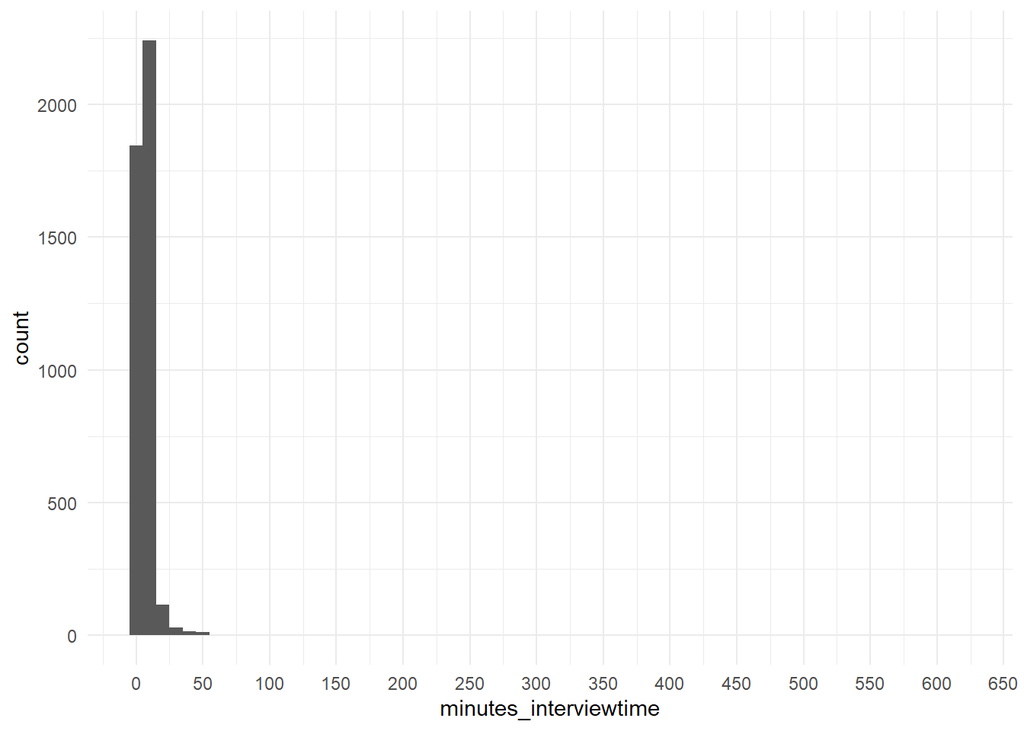

```r
dat_dupl_rem <- dat_dupl_rem %>%
   mutate(minutes_interviewtime = interviewtime / 60)

dat_dupl_rem %>% ggplot(aes(minutes_interviewtime))+
   geom_histogram(binwidth = 10)+
   scale_x_continuous(breaks = seq(0,650, by = 50))+
   theme_minimal()
```

Generally, our group has done the survey as well, and it took around 8 to 11 minutes to genuinely fill out the survey.  
Lets take out the outliers on the upper end who would be defined as “outliers” by taking out the top 5 percentile, leaving us with the bottom 95% of the dataset.

Here is a short summary what we would have left after taking out these heavy outliers (again in minutes):

```r
upper_95 <- quantile(dat_dupl_rem$minutes_interviewtime, .95)

dat_dupl_rem <- dat_dupl_rem %>% mutate(considered_bad = if_else(minutes_interviewtime >= upper_95, 1, 0))


summary_speed <- dat_dupl_rem %>% filter(considered_bad == 0) %>%
   summarize(
      mean_time = mean(minutes_interviewtime),
      sd_time = sd(minutes_interviewtime),
      min_time = min(minutes_interviewtime),
      max_time = max(minutes_interviewtime)
   )

summary_speed
```

```
## # A tibble: 1 × 4
##   mean_time sd_time min_time max_time
##       <dbl>   <dbl>    <dbl>    <dbl>
## 1      5.74    2.48     1.64     14.3
```

Distributions after taking out the heavy outliers:

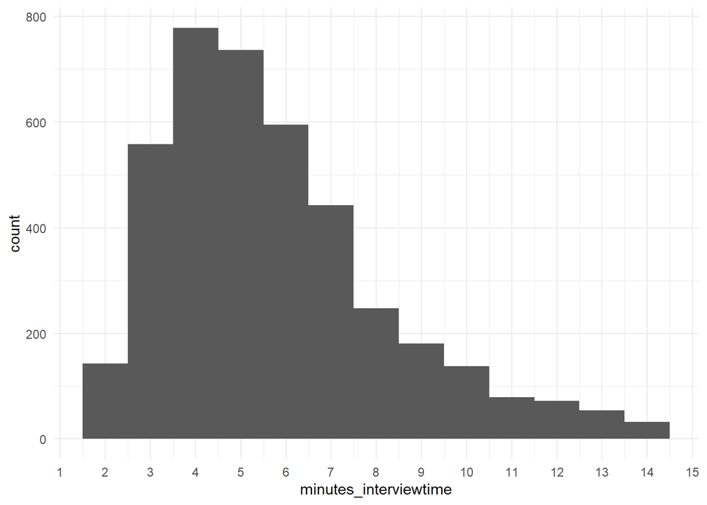

```r
dat_dupl_rem %>%
   filter(considered_bad == 0) %>%
   ggplot(aes(minutes_interviewtime))+
   geom_histogram(binwidth = 1)+
   scale_x_continuous(breaks = seq(0,60, by = 1))+
   theme_minimal()
```

Additionally, we’ll create 2 other datasets as mentioned above:  
- Dataset with the lower limit of 3 minutes (giving the participants less than 5 seconds to complete the 36 risks questions, not including informed consent, and the demographics etc.)  
- Dataset with the lower limit of 5 minutes, providing a more realistic threshold for data quality

```r
mean_time <- summary_speed$mean_time
sd_time <- summary_speed$sd_time

no_low_thresh <- dat_dupl_rem %>%
   filter(considered_bad == 0)

low_3_thresh <- no_low_thresh %>% filter(minutes_interviewtime >= 3) %>%
   mutate(Threshold = 3)
low_5_thresh <- no_low_thresh %>% filter(minutes_interviewtime >= 5) %>%
   mutate(Threshold = 5)
```

Here is a quick display in how the distributions for each created dataset looks like:

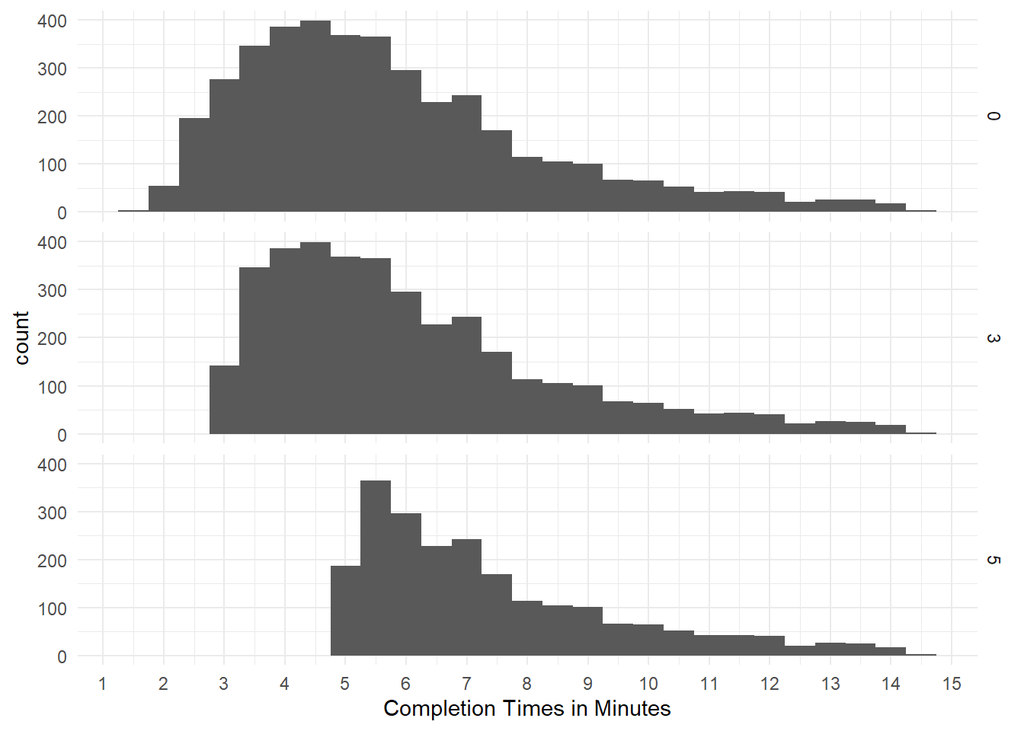

```r
all_thresholds_data <- no_low_thresh %>% mutate(Threshold = 0) %>%
   rbind(low_3_thresh, low_5_thresh)

all_thresholds_data %>%
   ggplot(aes(minutes_interviewtime))+
   geom_histogram(binwidth = .5)+
   scale_x_continuous(breaks = seq(0,20, by = 1)) +
   facet_grid(rows = vars(Threshold))+
   labs(x = "Completion Times in Minutes")+
   theme_minimal()
```

Here is a barplot indicating how many participant are in the different Thresholds, colored by Country of origin:

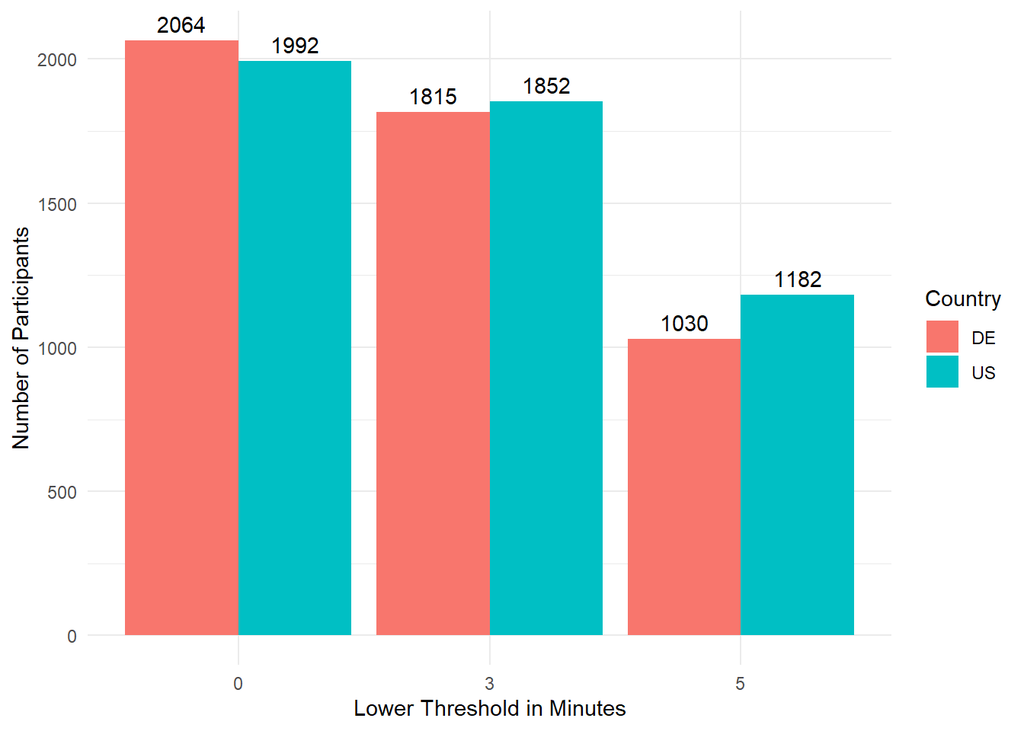

```r
all_thresholds_data %>% group_by(Threshold, Country) %>%
   summarize("Number of Participants" = n()) %>%
   ggplot(aes(factor(Threshold), `Number of Participants`, fill = Country))+
   geom_bar(stat = "identity", position = "dodge")+
   labs(x = "Lower Threshold in Minutes")+
   geom_text(aes(label = `Number of Participants`), vjust = -.5, position =  position_dodge(width = .9))+
   theme_minimal()
```

## Saving to Excel

Save the data into a excel file:

```r
# create excel file into R environment
wb <- loadWorkbook(create = T, filename = "newest_dat_file.xls")

# create sheets in the same file, giving them intuitive names
createSheet(wb, name = "raw_only")
createSheet(wb, name = "0_min")
createSheet(wb, name = "3_min")
createSheet(wb, name = "5_min")

# load data into the specific sheets
writeWorksheet(wb, combined_dat_selected, sheet = "raw_only")
writeWorksheet(wb, no_low_thresh, sheet = "0_min")
writeWorksheet(wb, low_3_thresh, sheet = "3_min")
writeWorksheet(wb, low_5_thresh, sheet = "5_min")

# save data and export
saveWorkbook(wb)
```